# Introduction to priorCON

Christos Adam, Nikolaos Nagkoulis, Aggeliki Doxa, Antonios D. Mazaris, Stelios Katsanevakis

**This research was conducted at the Department of Marine Sciences, University of the Aegean, Greece, supported by the European Union’s Horizon 2020 research and innovation programme HORIZON-CL6–2021-BIODIV-01–12, under grant agreement No 101059407, “MarinePlan – Improved transdisciplinary science for effective ecosystem-based maritime spatial planning and conservation in European Seas”.**

# **Introduction to the priorCON Package (tutorial)**

The **priorCON** package offers an innovative tool-set that incorporates graph community detection methods into systematic conservation planning. This package is designed to enhance spatial prioritization by focusing on the protection of areas with high ecological connectivity. Unlike traditional approaches that prioritize individual planning units, **priorCON** focuses on clusters of features that exhibit strong ecological linkages. The **priorCON** package is built upon the **prioritizr** package (Hanson et al., 2026; 2025), using commercial and open-source exact algorithm solvers that ensure optimal solutions to prioritization problems.

**Features of priorCON**

- **Graph Community Detection**: The package utilizes connectivity metrics to identify clusters of habitat patches with high connectivity values.
- **Spatial prioritization**: The package uses the connectivity metrics as inputs in prioritizr to identify areas with high connectivity.
- **Connectivity Estimation**: The package estimates the connectivity protection level by calculating the protected connections.
- **Post-processing**: The package can be used to produce and download the outputs of the analysis as shapefiles, matrices and tmap plots.

This workflow is shown on Fig. 1.

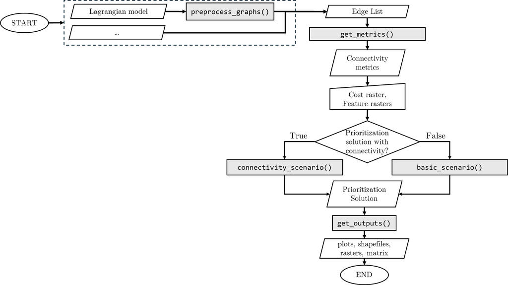

Fig. 1: Flow chart of the **priorCON** prioritization analysis. **priorCON** functions are indicated in grey boxes

This tutorial will guide you through the key functions of the package, from data preparation to generating informative outputs to address conservation connectivity challenges in diverse ecosystems.

## **Workflow: Running the analysis**

The package provides 4 steps to perform the analysis:

1. Preprocessing (Optional): Function `preprocess_graphs()` is built in order to create edge lists from various inputs formats.
2. Connectivity metrics estimation: Function `get_metrics()` is built to calculate the following graph metrics: degree, eigenvector centrality, betweenness centrality, louvain clustering, walktrap clustering, s-core, PageRank.
3. Prioritization: Functions `basic_scenario()` and `connectivity_scenario()` are used to insert the data to **prioritizr** run the prioritization problem and obtain the optimum solutions.
4. Post-processing: Function `get_outputs()` is used in order to plot interactive maps and export tables, shapefiles and rasters of the results

The functions of steps 1 and 2 can be used within the spatial conservation planning workflow as described here but also independently to create and obtain the graph metrics that might be also useful within other research contexts. In the next sections we provide an illustrative example to explain in more detail how the functions operate.

## **Installation**

All the functions of the package can be installed from CRAN in R via

```r
install.packages("priorCON")
```

Alternatively, the package **priorCON** can be installed at the development version from Github in R via

```r
if (!require(remotes)) install.packages("remotes")
remotes::install_github("cadam00/priorCON")
```

## **Illustration example**

Let us consider the following dataset as an illustrative example. The area examined is Thermaikos gulf in Greece. In this example, a Lagrangian model has been run to the area, to estimate connectivity. This connectivity will be incorporated into the analysis to obtain the areas that need to be protected to maximize the connectivity protection. Preprocessing is necessary in this case in order to transform the Lagrangian data in an edge list.

### Step 1 Preprocessing (Optional):

The input of an edge list is required in most graph theoretic approaches. Fig. 2 represents a typical directed weighted graph. In the edge list, the first two columns utilize the nodes IDs to represent edges and the last column corresponds to the value of the edges. This value actually represents the connectivity value between the corresponding nodes and may represent for instance values resulting from particle drift models, migration probabilities or other. This preprocessing step can be conducted using the function `preprocess_graphs()` and serves in reading and transforming the initial input data into an edge list. Further details on the initial data formats are given below. In case that an edge list is available, this step can be skipped.

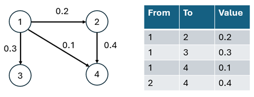

Fig. 2: Weighted directed graph (left): Circles represent nodes and arrows represent weighted edges. The tabular representation of the graph represents the edge list (right).

Function `preprocess_graphs()` takes as input a list of .txt/.csv objects. Each object represents the connections between a node and all the other nodes. For the model to read the data, it is necessary to have all the .txt/.csv objects in one folder. There are two ways to incorporate connectivity data, based on their linkage to features:

- Case 1: the connectivity data correspond to specific biodiversity features. If a biodiversity feature has its own connectivity dataset then the file including the edge lists needs to have the same name as the corresponding feature. For example, consider having 5 species (f1, f2, f3, f4, f5) and 5 connectivity datasets. Then the connectivity datasets need to be in separate folders named: f1,f2,f3,f4,f5 and the algorithm will understand that they correspond to the species.
- Case 2: the connectivity dataset represents a spatial pattern that is not directly connected with a specific biodiversity feature. Then the connectivity data need to be included in a separate folder named in a different way than the species. For example consider having 5 species (f1,f2,f3,f4,f5) and 1 connectivity dataset. This dataset can be included in a separate folder (e.g. “Langragian_con”).

In our example we use connectivity values that are not directly connected with a specific species, therefore we illustrate Case 2. Fig. 3 represents the structure used in the tutorial. The data need to be stored in this way in order for the algorithm to read them properly.

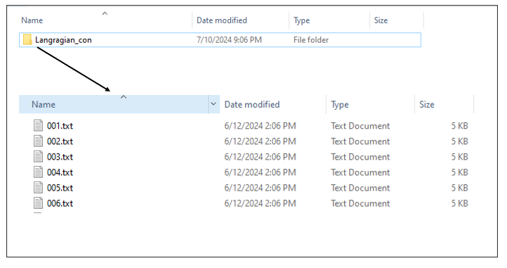

Fig. 3: Connectivity folder

A typical Lagrangian output is a set of files representing the likelihood of a point moving from an origin (source) to a destination (target). This can be represented using a list of .txt files (as many as the origin points) including information for the destination probability. The .txt files need to be named in an increasing order. The name of the files need to correspond to the numbering of the points, in order for the algorithm to match the coordinates with the points (Fig. 4).

[figure not shown]

Fig. 4: The 001.txt file contains the following information: Each row represents the probability of movement between point 001 and any other destination points.

As long as the data are set in this way, the preprocessing algorithm can run and transform the format of the inputs to an edge list. If an edge list dataset is available, this preprocessing step can be skipped.

```r
# Import packages
library(priorCON)
library(tmap)
library(terra)
```

```r
# Read connectivity files from folder and combine them
  combined_edge_list <- preprocess_graphs(
    system.file("external",package="priorCON"),
    header = FALSE, sep =";"
   )
```

### Step 2 Connectivity Metrics Estimation:

Function `get_metrics()` is used to calculate graph metrics values. The edge lists created from the previous step, or inserted directly from the user are used in this step to create graphs. The directed graphs are transformed to undirected. The function is based on the **igraph** package (Csárdi and Nepusz, 2006; Csárdi et al., 2026) which is used to create clusters using Louvain and Walktrap and calculate the following metrics: Eigenvector Centrality, Betweenness Centrality, Degree and PageRank. S-core is calculated using the package **brainGraph** (Watson, 2026). The user can choose between these options to create the respective outputs. `'s_core'`, `'louvain'`, `'walktrap'`, `'eigen'`, `'betw'`, `'deg'` or `'page_rank'`.

Detailed information on the theory and equations of the used graph metrics are provided in Nagkoulis et al.(2026; subm Methods in Ecology and Evolution).

```r
# Set seed for reproducibility
set.seed(42)

# Detect graph communities using the s-core algorithm
pre_graphs <- get_metrics(combined_edge_list, which_community = "s_core")
```

### Step 3 Prioritization:

Two alternative functions can be used for the prioritization step: i) the `connectivity_scenario()` function, which includes connectivity into the optimization procedure and ii) the `basic_scenario()` function, which does not include connectivity. The two functions can be run separately. Users may use both functions, if they wish to compare the results obtained from the two scenarios, i.e. with and without connectivity. Alternatively, only the `connectivity_scenario()` function can be run to obtain the prioritization outputs of the connectivity scenario. Both functions are based on the **priorititizr** package (Hanson et al., 2026; 2025). The connectivity metrics are first transformed to rasters, following an approach similar to Marxan Connect (Daigle et al., 2020). Then **priorititizr** maximizes the utility obtained from protecting both features and connections. Mathematically, the target of the optimization is to maximize U under the budget (B) limitations (eq. 2 and 3 of Nagkoulis et al. (2026)):

$$U = \sum_{\boldsymbol{PU_i} \, \in \,SA} -\lambda c_i +
\sum_{\boldsymbol{PU_i} \, \in \,SA} \sum_{j=1}^J \mu_j f_j +
\sum_{\boldsymbol{PU_i} \, \in \,SA} \sum_{j=1}^J \mu_j M_j,$$

$$\sum_{\boldsymbol{PU_i} \, \in \, SA} c_i \leq B$$

A set of planning units $\boldsymbol{A}=(\boldsymbol{PU}_1, \boldsymbol{PU}_2, ..., \boldsymbol{PU_i}, ..., \boldsymbol{PU_i})$ is considered to be protected when $\boldsymbol{PU_i} \, \in \, SA$. The protection of any $\boldsymbol{PU_i}$ results in a cost $c_i$. A finite set of features $\boldsymbol{F}=(F_1, F_2, ... , F_j, ..., F_J)$ is also distributed in $A$, suggesting that these features can be spatially mapped within the PUs. Each $PU$ is thus defined as a spatial object containing the following properties: $\boldsymbol{PU_i}=(f_1, f_2, ..., f_j, ..., f_J, c_i)$, where $f_j$ indicates the quantity of $F_j$ located in $PU_i$. We use the annotation $M_j$ for the values of the metric for every feature $j$. By inserting metrics into the analysis, each PU’s ($\boldsymbol{PU_i}$) properties are extended and can be expressed as follows: $\boldsymbol{PU_i} = (f_1, f_2, ..., f_j, ..., f_J, M_1, M_2, ..., M_j, ..., M_J, c_i)$.

The first input that can be given to the algorithm is a typical cost layer representing the cost of protecting each single planning unit. This cost layer is inserted to **prioritizr**. If such a cost layer is not available, a cost layer with all planning units having equal cost can be inserted (Fig. 5. The algorithm needs a cost layer, in order to determine the planning units.

```
## The visual variable "col" of the layer "raster" contains a unique value. Therefore a discrete scale is applied (tm_scale_discrete).
```

[figure not shown]

Fig. 5: Cost raster

```r
# Set tmap to “view” mode
tmap_mode("view")

# Read the cost raster
cost_raster <- get_cost_raster()

# Plot the cost raster with tmap
tm_shape(cost_raster) +
  tm_raster(col.legend = tm_legend(title = "cost",
            position = c("right", "top")))
```

The second input are the features rasters. In case such rasters are not available, a raster with equal values can be given to the algorithm. In this case we have used such a pseudo-raster, adding some noise to improve the performance of the algorithm.

[figure not shown]

Fig. 6: Features raster

```r
# Read the features raster
features <- get_features_raster()

# Plot the features raster with tmap
tm_shape(features) +
  tm_raster(col.legend = tm_legend(title = "f1",
            position = c("right", "top")))
```

```r
# Solve an ordinary prioritizr prioritization problem
basic_solution <- basic_scenario(
                    cost_raster = cost_raster,
                    features    = features,
                    budget_perc = 0.1
                  )

# Solve a prioritizr prioritization problem,
# by incorporating graph connectivity of the features
connectivity_solution <- connectivity_scenario(
                           cost_raster = cost_raster,
                           features    = features,
                           budget_perc = 0.1,
                           pre_graphs  = pre_graphs
                         )
```

### Step 4: Post-processing:

The results obtained from **prioritizr** are presented using matrices and plots, allowing the user to compare the outcomes of incorporating connectivity metrics in the analysis. Function `get_outputs()` takes as input a prioritization solution. The user can also get the outputs as shapefiles and raster to use them in their analysis.

```
The visual variable "col" of the layer "lines" contains a unique value. Therefore a discrete scale is applied (tm_scale_discrete).
```

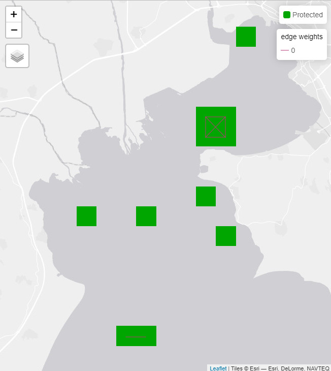

Fig. 7: Basic solution with connections shown

```r
 # Get outputs from basic_scenario function for feature “f1”
basic_outputs <- get_outputs(solution   = basic_solution,
                             feature    = "f1",
                             pre_graphs = pre_graphs)
basic_outputs$tmap
```

```r
# Print summary of features and connections held
# percentages for basic scenario
print(basic_outputs$connectivity_table)
```

```r
##  feature relative_held connections(%)
## 1     f1      0.178563              0
```

[figure not shown]

Fig. 8: Connectivity solution with connections shown

```r
# Get outputs from connectivity_scenario function for feature “f1”
connectivity_outputs <- get_outputs(solution   = connectivity_solution,
                                    feature    = "f1",
                                    pre_graphs = pre_graphs)
connectivity_outputs$tmap
```

```r
# Print summary of features and connections held percentages
# for connectivity scenario
print(connectivity_outputs$connectivity_table)
```

```r
##  feature relative_held connections(%)
## 1     f1     0.1637209      0.3339886
```

### Graph Connectivity Rasters:

Accessing and working directly with the graph connectivity rasters used as features in the `connectivity_scenario` function is possible by two ways. The first way is after running `connectivity_scenario`, retrieving its output elements named `original_connectivity_rast`/`normalized_connectivity_rast`. The second one is computing these rasters directly from `get_metrics` output and a planning units SpatRaster object (`pu_raster`).

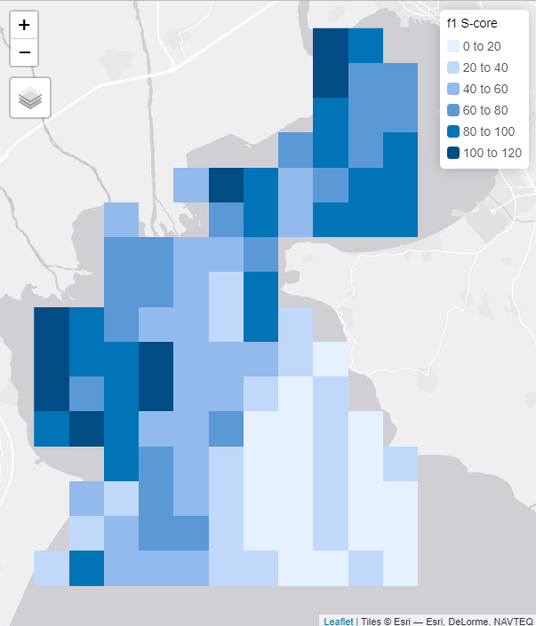

Fig. 9: Graph connectivity

```r
# Define planning units area SpatRaster, matching the coordinates of pre_graphs
pu_raster <- get_cost_raster()
# Graph connectivity SpatRaster object. pre_graphs is calculated as before.
# It has same values with connectivity_solution$original_connectivity_rast
f1_s_core <- graph_connectivity_rasters(pu_raster, pre_graphs)

# Plot the graph connectivity SpatRaster with tmap.
tm_shape(f1_s_core) +
  tm_raster(col.legend = tm_legend(title = "f1 S-core",
            position = c("right", "top")))
```

[figure not shown]

Fig. 10: Normalized graph connectivity

```r
# Plot normalized graph connectivity SpatRaster with tmap in [0,1] scale.
# It has same values with connectivity_solution$normalized_connectivity_rast.

max_ <- as.numeric(global(f1_s_core, max, na.rm=TRUE))
min_ <- as.numeric(global(f1_s_core, min, na.rm=TRUE))
f1_s_core_normalized <- (f1_s_core - min_) / (max_ - min_)

tm_shape(f1_s_core_normalized) +
  tm_raster(col.legend = tm_legend(title = "Normalized f1 S-core",
            position = c("right", "top")))
```

## **References**

Csárdi, Gábor, and Tamás Nepusz. 2006. “The igraph software package for complex network research.” *InterJournal* Complex Systems: 1695. https://igraph.org

Csárdi, Gábor, Tamás Nepusz, Vincent Traag, Szabolcs Horvát, Fabio Zanini, Daniel Noom, and Kirill Müller. 2026. *igraph: Network Analysis and Visualization in R*. https://doi.org/10.5281/zenodo.7682609

Daigle, Rémi M., Anna Metaxas, Arieanna C. Balbar, Jennifer McGowan, Eric A. Treml, Caitlin D. Kuempel, Hugh P. Possingham, and Maria Beger. 2020. “Operationalizing ecological connectivity in spatial conservation planning with Marxan Connect.” *Methods in Ecology and Evolution* 11 (4): 570–79. https://doi.org/10.1111/2041-210X.13349

Hanson, Jeffrey O, Richard Schuster, Nina Morrell, Matthew Strimas-Mackey, Brandon P M Edwards, Matthew E Watts, Peter Arcese, Joseph R Bennett, and Hugh P Possingham. 2026. **prioritizr: Systematic Conservation Prioritization in R**. https://CRAN.R-project.org/package=prioritizr

Hanson JO, Schuster R, Strimas‐Mackey M, Morrell N, Edwards BPM, Arcese P, Bennett JR, and Possingham HP. 2025. Systematic conservation prioritization with the prioritizr R package. *Conservation Biology*, 39: e14376. https://doi.org/10.1111/cobi.14376

Watson, Christopher G. 2026. **brainGraph: Graph Theory Analysis of Brain MRI Data**. https://doi.org/10.32614/CRAN.package.brainGraph